# Replication of Study: Why Do Skilled Immigrants Struggle in the Labor Market? A Field Experiment with Thirteen Thousand Resumes

Junaid Ahmed

27 April, 2020

Abstract

A replication of a study done to analyze why immigrants struggle in the labor market.

# 1 Introduction

This study was originally completed by Philip Oreopoulos at the Abdul Latif Jameel Poverty Action Lab. He attempted to answer, “Why Do Skilled Immigrants Struggle in the Labor Market? A Field Experiment with Thirteen Thousand Resumes” His findings noted a few countries of origin that were discriminated against, but no other variables correlated.

The study only contains tables with correlations and various mathematical analyses. I will focus on recreating the linear model.

https://dataverse.harvard.edu/dataset.xhtml?persistentId=doi:10.7910/DVN/WXMJCN

## 1.1 The Story Behind the Data

“Thousands of randomly manipulated resumes were sent in response to online job postings in Toronto to investigate why immigrants, allowed in based on skill, struggle in the labor market. The study finds substantial discrimination across a variety of occupations towards applicants with foreign experience or those with Indian, Pakistani, Chinese, and Greek names compared with English names. Listing language fluency, multinational firm experience, education from highly selective schools, or active extracurricular activities had no diminishing effect. Recruiters justify this behavior based on language skill concerns but fail to fully account for offsetting features when listed.”

## 1.2 Why it was gathered

The data was generated in order to examine whether discrimination was a viable explanation for difficulties with immigrant job search

## 1.3 Personal Interest in the Data

I would like to work with within the fields of immigration, education, poverty and policy, so this was interesting to me. This data was from a poverty lab, and I have applied to a few poverty labs for summer work experience

# 2 Initializing

## 2.1 Install Libraries

```r
#Installs libraries if not found already on computer
neededPackages <- c("tidyverse", "haven", "knitr", "kableExtra", "stargazer", "cowplot", "ggthemes", "psych", "corrplot")
                #add more packages if needed here
for (i in neededPackages){
  if (!is.element(i, .packages(all.available = TRUE)) ) {
    install.packages(i)
  }
  library(i,character.only = TRUE)
}

options(kableExtra_latex_packages = FALSE, knitr.table.format = "html", knitr.kable.NA = '')
```

## 2.2 Import Data

```r
df <- haven::read_dta("oreopoulos resume study replication data file.dta")
```

# 3 Initial Look at the Data

```r
head(df)
```

| firmid | occupation_type | name_ethnicity | additional_credential | name | language_skills | accreditation | reference | legal | listedaccreditation | city | ma | female | certificate | ba_quality | exp_highquality | callback | interview | second_callback | type | extracurricular_skills | skillspeaking | skillsocialper | skillwriting | fall_data | chinese | indian | british | pakistani | Chn_Cdn | … |
| --- | --- | --- | --- | --- | --- | --- | --- | --- | --- | --- | --- | --- | --- | --- | --- | --- | --- | --- | --- | --- | --- | --- | --- | --- | --- | --- | --- | --- | --- | --- |
| -3 | Administrative | Canada | 0 | JillWilson | 0 | 0 | 0 | 0 | 0 | Toronto | 0 | 1 | 0 | 1 | 0 | 0 | 0 | 0 | 0 | 0 | 70 | 50 | 67 | 2 | NA | NA | NA | NA | NA | … |
| -3 | Administrative | Indian | 0 | PanavSingh | 0 | 0 | 0 | 0 | 0 | Toronto | 0 | 0 | 0 | 1 | 0 | 0 | 0 | 0 | 1 | 0 | 70 | 50 | 67 | 2 | NA | NA | NA | NA | NA | … |
| -3 | Administrative | Indian | 0 | RahulKaur | 0 | 0 | 0 | 1 | 1 | Toronto | 0 | 0 | 0 | 0 | 0 | 0 | 0 | 0 | 4 | 1 | 70 | 50 | 67 | 2 | NA | NA | NA | NA | NA | … |
| -3 | Administrative | Chinese | 0 | LeiLi | 0 | 1 | 1 | 0 | 1 | Toronto | 0 | 0 | 0 | 0 | 0 | 0 | 0 | 0 | 3 | 1 | 70 | 50 | 67 | 2 | NA | NA | NA | NA | NA | … |
| -4 | Administrative | Indian | 0 | MayaKumar | 1 | 0 | 0 | 0 | 0 | Toronto | 0 | 1 | 0 | 1 | 0 | 0 | 0 | 0 | 3 | 0 | 80 | 70 | 65 | 2 | NA | NA | NA | NA | NA | … |
| -4 | Administrative | Canada | 0 | GregJohnson | 0 | 0 | 0 | 0 | 0 | Toronto | 0 | 0 | 0 | 1 | 0 | 0 | 0 | 0 | 0 | 1 | 80 | 70 | 65 | 2 | NA | NA | NA | NA | NA | … |

The Variables that we have are:

- **frimid:** job-posting identification number
- **occupation_type:** job and resume occupation category
- **name_ethnicity:** name ethnicity
- **additional_credential:** indicator for additional credential added to all 4 resume types sent to employer because posting required it
- **name:** name
- **language_skills:** fluency in french and, for ethnic names, corresponding foreign language
- **accreditation:** indicator for noting degree is accredited by the Canadian International Skills Certification Board
- **reference:** indicator for canadian references listed
- **legal:** indicator for permanent residency status
- **city:** toronto, montreal, or vancouver
- **ma:** indicator for resume listing masters degree
- **female:** indicator for female name
- **ba_quality:** indicator for whether bachelors’ degree from top ranked school
- **exp_highquality:** indicator for whether experience from very large firm
- **callback:** indicator that resume received callback
- **interview:** indicator that interview specifically mentioned in callback
- **second_callback:** indicator that resume received two callbacks
- **type:**
  - **Type 0:** an applicant with an English sounding name, Canadian undergraduate education, and Canadian experience
  - **Type 1**: a foreign sounding name (Chinese, Indian, Pakistani, or Greek), but still listed Canadian undergraduate education and Canadian experience
  - **Type 2:** a foreign sounding name (Chinese, Indian, or Pakistani), corresponding foreign undergraduate degree, and Canadian experience
  - **Type 3:** a foreign sounding name, foreign education, and some foreign experience
  - **Type 4:** a foreign sounding name, foreign education, and all foreign experience
- **extracurricular_skills:** indicator for whether (active) extracurricular skills listed
- **skillspeaking:** ONET skill-speaking skills
- **skillsocialper:** ONET skill social and personal skills
- **skillwriting:** ONET skill writing skills
- **fall_data:** indicator for 3 resume collection periods (see text)
- **same_exp:** indicator for same firms listed across 4 resumes sent to same job

## 3.1 Data Cleaning

Now that the data has been imported, I will clean the variables we do not need. In particular, the last few columns indicate ethnicity in `wide` format, which we do not need.

```r
#Removes columns which contain all NA values
df <- select(df, -c(chinese:same_exp))
```

# 4 Data Tables Replications

Although tables were provided, I will replcate the main tables here for easier viewing and to demonstrate my use of `kable()` beyond what was learned in class.

## 4.1 Table 2A Replication

### 4.1.1 Original Table

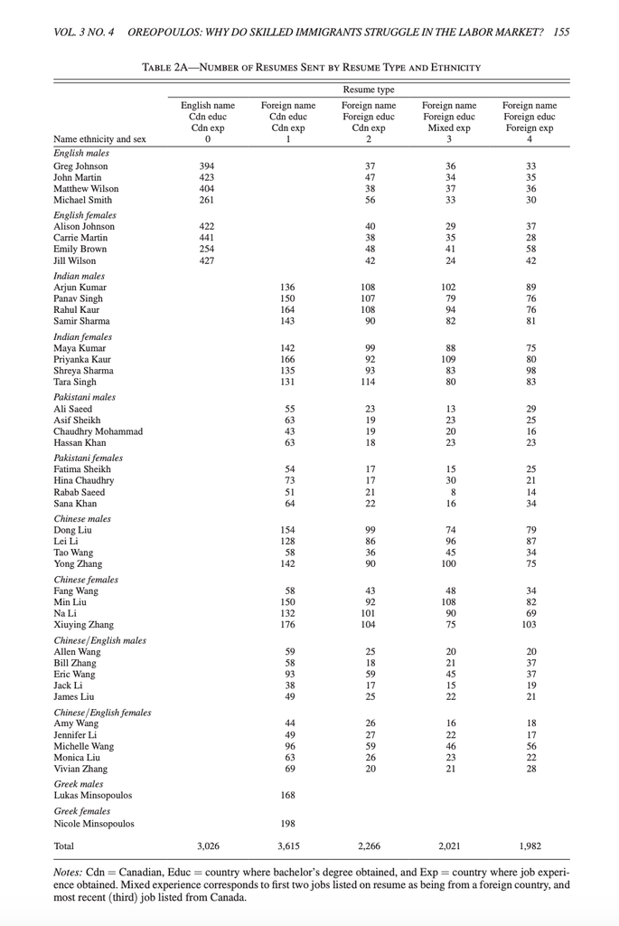

### 4.1.2 Preprocessing:

```r
#British and Canadian names are English in this table
df$name_ethnicity <- recode(df$name_ethnicity, British = "English", Canada = "English")

#Ethnicity sorted by order given in table
levels <- c("English", "Indian", "Pakistani", "Chinese", "Chn-Cdn", "Greek")

#Obtains necessary variables for table
data <- data.frame(type = df$type,
                   name = df$name,
                   fall_data = df$fall_data,
                   ethnicity = factor(df$name_ethnicity, levels=levels),
                   female = df$female)

#Obtains Proper Name using regex
data$name <- trimws(gsub('([[:upper:]])', ' \\1', data$name))

#Obtains total resumes sent out by ethnicity
colSums <-
  data %>%
  group_by(type) %>%
  summarize(sum(fall_data)) %>%
  pivot_wider(names_from = type, values_from = `sum(fall_data)`) %>%
  cbind(name = "Total", .)

#Summarizes results by resume frequency
data <-
  data %>%
  group_by(type, name, ethnicity, female) %>%
  summarise(sum(fall_data)) %>%
  pivot_wider(names_from = type, values_from = `sum(fall_data)`) %>%
  arrange(ethnicity, female) %>%
  ungroup() %>%
  select(-c(ethnicity, female)) %>%
  add_row(colSums)
```

### 4.1.3 Replication

```r
#table source: https://haozhu233.github.io/kableExtra/awesome_table_in_pdf.pdf
kable(data, format="html", longtable = F, booktabs = T,
      caption = "TABLE 2A - NUMBER OF RESUMES SENT BY RESUME TYPE AND ETHNICITY", col.names = c("", "", "", "", "", "")) %>%
  kable_styling("striped") %>%
  pack_rows("English males", 1, 4) %>%
  pack_rows("English females", 5, 8) %>%
  pack_rows("Indian males", 9, 12) %>%
  pack_rows("Indian females", 13, 16) %>%
  pack_rows("Pakistani males", 17, 20) %>%
  pack_rows("Pakistani females", 21, 24) %>%
  pack_rows("Chinese males", 25, 28) %>%
  pack_rows("Chinese females", 29, 32) %>%
  pack_rows("Chinese/Englsh males", 33, 37) %>%
  pack_rows("Chinese/English females", 38, 42) %>%
  pack_rows("Greek males", 43, 43) %>%
  pack_rows("Greek females", 44, 44) %>%
  pack_rows("", 45, 45) %>%
  row_spec(row = c(1:nrow(data)), align = "c") %>%
  add_header_above(c("Name ethnicity and sex" = 1, 0, 1, 2, 3, 4)) %>%
  add_header_above(c("", "Cdn exp", "Cdn exp", "Cdn exp", "Mixed exp", "Foreign exp"), line = F) %>%
  add_header_above(c("", "Cdn educ", "Cdn educ", "Foreign educ", "Foreign educ", "Foreign educ"), line = F) %>%
  add_header_above(c("", "English name", "Foreign name", "Foreign name", "Foreign name", "Foreign name"), line = F) %>%
  add_header_above(c("", "", "", "Resume type", "", ""), line = T) %>%
  footnote(general_title = "Notes:", general = "Cdn = Canadian, Educ = country where bachelor’s degree obtained, and Exp = country where job experience obtained. Mixed experience corresponds to first two jobs listed on resume as being from a foreign country, and most recent (third) job listed from Canada.", title_format = "italic", footnote_as_chunk = T)
```

TABLE 2A - NUMBER OF RESUMES SENT BY RESUME TYPE AND ETHNICITY

| Name ethnicity and sex | English name Cdn educ Cdn exp 0 | Foreign name Cdn educ Cdn exp 1 | Resume type Foreign name Foreign educ Cdn exp 2 | Foreign name Foreign educ Mixed exp 3 | Foreign name Foreign educ Foreign exp 4 |
| --- | --- | --- | --- | --- | --- |
| **English males** |  |  |  |  |  |
| Greg Johnson | 459 |  | 37 | 36 | 33 |
| John Martin | 482 |  | 47 | 34 | 35 |
| Matthew Wilson | 488 |  | 38 | 37 | 36 |
| Michael Smith | 121 |  | 56 | 33 | 30 |
| **English females** |  |  |  |  |  |
| Alison Johnson | 456 |  | 40 | 29 | 37 |
| Carrie Martin | 493 |  | 38 | 35 | 28 |
| Emily Brown | 133 |  | 48 | 41 | 58 |
| Jill Wilson | 485 |  | 42 | 24 | 42 |
| **Indian males** |  |  |  |  |  |
| Arjun Kumar |  | 162 | 144 | 128 | 84 |
| Panav Singh |  | 150 | 138 | 82 | 80 |
| Rahul Kaur |  | 210 | 130 | 110 | 82 |
| Samir Sharma |  | 172 | 116 | 78 | 92 |
| **Indian females** |  |  |  |  |  |
| Maya Kumar |  | 182 | 144 | 116 | 76 |
| Priyanka Kaur |  | 216 | 108 | 110 | 78 |
| Shreya Sharma |  | 152 | 114 | 86 | 78 |
| Tara Singh |  | 154 | 124 | 88 | 90 |
| **Pakistani males** |  |  |  |  |  |
| Ali Saeed |  | 55 | 23 | 13 | 29 |
| Asif Sheikh |  | 63 | 19 | 23 | 25 |
| Chaudhry Mohammad |  | 43 | 19 | 20 | 16 |
| Hassan Khan |  | 63 | 18 | 23 | 23 |
| **Pakistani females** |  |  |  |  |  |
| Fatima Sheikh |  | 54 | 17 | 15 | 25 |
| Hina Chaudhry |  | 73 | 17 | 30 | 21 |
| Rabab Saeed |  | 51 | 21 | 8 | 14 |
| Sana Khan |  | 64 | 22 | 16 | 34 |
| **Chinese males** |  |  |  |  |  |
| Dong Liu |  | 184 | 118 | 76 | 84 |
| Lei Li |  | 128 | 82 | 124 | 88 |
| Tao Wang |  | 0 | 0 | 0 | 0 |
| Yong Zhang |  | 176 | 108 | 114 | 72 |
| **Chinese females** |  |  |  |  |  |
| Fang Wang |  | 0 | 0 | 0 | 0 |
| Min Liu |  | 170 | 112 | 106 | 90 |
| Na Li |  | 158 | 126 | 108 | 74 |
| Xiuying Zhang |  | 218 | 118 | 88 | 114 |
| **Chinese/Englsh males** |  |  |  |  |  |
| Allen Wang |  | 59 | 25 | 20 | 20 |
| Bill Zhang |  | 58 | 18 | 21 | 37 |
| Eric Wang |  | 186 | 118 | 90 | 74 |
| Jack Li |  | 38 | 17 | 15 | 19 |
| James Liu |  | 49 | 25 | 22 | 21 |
| **Chinese/English females** |  |  |  |  |  |
| Amy Wang |  | 44 | 26 | 16 | 18 |
| Jennifer Li |  | 49 | 27 | 22 | 17 |
| Michelle Wang |  | 192 | 118 | 92 | 112 |
| Monica Liu |  | 63 | 26 | 23 | 22 |
| Vivian Zhang |  | 69 | 20 | 21 | 28 |
| **Greek males** |  |  |  |  |  |
| Lukas Minsopoulos |  | 336 |  |  |  |
| **Greek females** |  |  |  |  |  |
| Nicole Minsopoulos |  | 396 |  |  |  |
| Total | 3117 | 4437 | 2604 | 2173 | 2036 |

Notes: Cdn = Canadian, Educ = country where bachelor’s degree obtained, and Exp = country where job experience obtained. Mixed experience corresponds to first two jobs listed on resume as being from a foreign country, and most recent (third) job listed from Canada.

## 4.2 Table 2B replication

### 4.2.1 Original Table

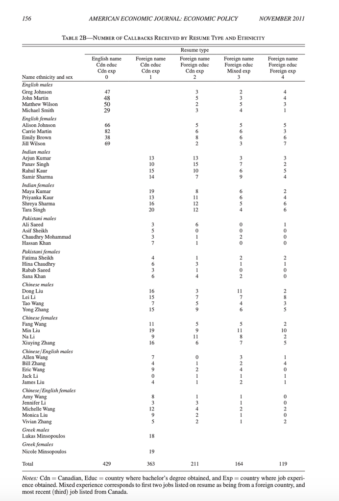

### 4.2.2 Preprocessing

```r
#British and Canadian names are English in this table
df$name_ethnicity <- recode(df$name_ethnicity, British = "English", Canada = "English")

#Ethnicity sorted by order given in table
levels <- c("English", "Indian", "Pakistani", "Chinese", "Chn-Cdn", "Greek")

#Obtains necessary variables for table
data2b <- data.frame(type = df$type,
                   name = df$name,
                   callback = df$callback,
                   ethnicity = factor(df$name_ethnicity, levels=levels),
                   female = df$female)

#Obtains Proper Name using regex
data2b$name <- trimws(gsub('([[:upper:]])', ' \\1', data2b$name))

#Obtains total resumes sent out by ethnicity
colSums <-
  data2b %>%
  group_by(type) %>%
  summarize(sum(callback)) %>%
  pivot_wider(names_from = type, values_from = `sum(callback)`) %>%
  cbind(name = "Total", .)

#Summarizes results by callback frequency
data2b <-
  data2b %>%
  group_by(type, name, ethnicity, female) %>%
  summarise(sum(callback)) %>%
  pivot_wider(names_from = type, values_from = `sum(callback)`) %>%
  arrange(ethnicity, female) %>%
  ungroup() %>%
  select(-c(ethnicity, female)) %>%
  add_row(colSums)
```

### 4.2.3 Replication

```r
#table source: https://haozhu233.github.io/kableExtra/awesome_table_in_pdf.pdf
kable(data2b, format="html", longtable = F, booktabs = T,
      caption = "TABLE 2B - CALLBACKS BY RESUME TYPE AND ETHNICITY", col.names = c("", "", "", "", "", "")) %>%
  kable_styling("striped") %>%
  pack_rows("English males", 1, 4) %>%
  pack_rows("English females", 5, 8) %>%
  pack_rows("Indian males", 9, 12) %>%
  pack_rows("Indian females", 13, 16) %>%
  pack_rows("Pakistani males", 17, 20) %>%
  pack_rows("Pakistani females", 21, 24) %>%
  pack_rows("Chinese males", 25, 28) %>%
  pack_rows("Chinese females", 29, 32) %>%
  pack_rows("Chinese/Englsh males", 33, 37) %>%
  pack_rows("Chinese/English females", 38, 42) %>%
  pack_rows("Greek males", 43, 43) %>%
  pack_rows("Greek females", 44, 44) %>%
  pack_rows("", 45, 45) %>%
  row_spec(row = c(1:nrow(data2b)), align = "c") %>%
  add_header_above(c("Name ethnicity and sex" = 1, 0, 1, 2, 3, 4)) %>%
  add_header_above(c("", "Cdn exp", "Cdn exp", "Cdn exp", "Mixed exp", "Foreign exp"), line = F) %>%
  add_header_above(c("", "Cdn educ", "Cdn educ", "Foreign educ", "Foreign educ", "Foreign educ"), line = F) %>%
  add_header_above(c("", "English name", "Foreign name", "Foreign name", "Foreign name", "Foreign name"), line = F) %>%
  add_header_above(c("", "", "", "Resume type", "", ""), line = T) %>%
  footnote(general_title = "Notes:", general = "Cdn = Canadian, Educ = country where bachelor’s degree obtained, and Exp = country where job experience obtained. Mixed experience corresponds to first two jobs listed on resume as being from a foreign country, and most recent (third) job listed from Canada.", title_format = "italic", footnote_as_chunk = T)
```

TABLE 2B - CALLBACKS BY RESUME TYPE AND ETHNICITY

| Name ethnicity and sex | English name Cdn educ Cdn exp 0 | Foreign name Cdn educ Cdn exp 1 | Resume type Foreign name Foreign educ Cdn exp 2 | Foreign name Foreign educ Mixed exp 3 | Foreign name Foreign educ Foreign exp 4 |
| --- | --- | --- | --- | --- | --- |
| **English males** |  |  |  |  |  |
| Greg Johnson | 47 |  | 3 | 2 | 4 |
| John Martin | 48 |  | 5 | 3 | 4 |
| Matthew Wilson | 50 |  | 2 | 5 | 3 |
| Michael Smith | 29 |  | 3 | 4 | 1 |
| **English females** |  |  |  |  |  |
| Alison Johnson | 66 |  | 5 | 5 | 5 |
| Carrie Martin | 82 |  | 6 | 6 | 3 |
| Emily Brown | 38 |  | 8 | 6 | 6 |
| Jill Wilson | 69 |  | 2 | 3 | 7 |
| **Indian males** |  |  |  |  |  |
| Arjun Kumar |  | 13 | 13 | 3 | 5 |
| Panav Singh |  | 10 | 15 | 7 | 2 |
| Rahul Kaur |  | 15 | 10 | 6 | 5 |
| Samir Sharma |  | 14 | 7 | 9 | 4 |
| **Indian females** |  |  |  |  |  |
| Maya Kumar |  | 19 | 8 | 6 | 2 |
| Priyanka Kaur |  | 13 | 11 | 6 | 4 |
| Shreya Sharma |  | 16 | 12 | 5 | 6 |
| Tara Singh |  | 20 | 12 | 4 | 6 |
| **Pakistani males** |  |  |  |  |  |
| Ali Saeed |  | 3 | 6 | 0 | 1 |
| Asif Sheikh |  | 5 | 0 | 0 | 0 |
| Chaudhry Mohammad |  | 3 | 1 | 2 | 0 |
| Hassan Khan |  | 7 | 1 | 0 | 0 |
| **Pakistani females** |  |  |  |  |  |
| Fatima Sheikh |  | 4 | 1 | 2 | 2 |
| Hina Chaudhry |  | 6 | 3 | 1 | 1 |
| Rabab Saeed |  | 3 | 1 | 0 | 0 |
| Sana Khan |  | 6 | 4 | 2 | 0 |
| **Chinese males** |  |  |  |  |  |
| Dong Liu |  | 16 | 3 | 11 | 2 |
| Lei Li |  | 15 | 7 | 7 | 8 |
| Tao Wang |  | 7 | 5 | 4 | 3 |
| Yong Zhang |  | 15 | 9 | 6 | 5 |
| **Chinese females** |  |  |  |  |  |
| Fang Wang |  | 11 | 5 | 5 | 2 |
| Min Liu |  | 19 | 9 | 11 | 10 |
| Na Li |  | 9 | 11 | 8 | 2 |
| Xiuying Zhang |  | 16 | 6 | 7 | 5 |
| **Chinese/Englsh males** |  |  |  |  |  |
| Allen Wang |  | 7 | 0 | 3 | 1 |
| Bill Zhang |  | 4 | 1 | 2 | 4 |
| Eric Wang |  | 9 | 2 | 4 | 0 |
| Jack Li |  | 0 | 1 | 1 | 1 |
| James Liu |  | 4 | 1 | 2 | 1 |
| **Chinese/English females** |  |  |  |  |  |
| Amy Wang |  | 8 | 1 | 1 | 0 |
| Jennifer Li |  | 3 | 3 | 1 | 0 |
| Michelle Wang |  | 12 | 4 | 2 | 2 |
| Monica Liu |  | 9 | 2 | 1 | 0 |
| Vivian Zhang |  | 5 | 2 | 1 | 2 |
| **Greek males** |  |  |  |  |  |
| Lukas Minsopoulos |  | 18 |  |  |  |
| **Greek females** |  |  |  |  |  |
| Nicole Minsopoulos |  | 19 |  |  |  |
| Total | 429 | 363 | 211 | 164 | 119 |

Notes: Cdn = Canadian, Educ = country where bachelor’s degree obtained, and Exp = country where job experience obtained. Mixed experience corresponds to first two jobs listed on resume as being from a foreign country, and most recent (third) job listed from Canada.

# 5 Empirical Question and Methodology

## 5.1 Question

I would like to see whether there are other factors that may mitigate resume discrimination. For example, can we showcase graduate education or high-ranking bachelor degrees to quell concerns of competency among foreign individuals?

## 5.2 Equation

I will test bachelor’s education ranking, work experience, and whether or not the person has a Master’s degree. Our goal is to look for factors that curb potential discrimination.

In our econometric model, our independent variable will be the characteristics available to us such as education level, and our dependent variable will be the rate of job callbacks.

The regression equation given by the study is: $y_{ijt} = \delta_0 + \delta_1Resume\_Type_{ijt} + \delta_2\textbf{X}_{ijt} + \delta_3[Resume\_Type_{ijt} \times \textbf{X}_{ijt}] + v_t + e_{ijt}$

Explanation:

“Where $y_{ijt}$ is an indicator variable for whether resume $i$ sent to job posing $j$ in period $t$ generated a call back, $Resume\_Type_{ijt}$ is an indicator variable for resume type, with the indicator for Type 0 being omitted. $\textbf{X}_{ijt}$ is a vector of other resume characteristics. Equation (1) allows for interactions between resume type and other characteristics. This allows me to estimate, for example, whether callback differences between resumes with English and Chinese sounding names become smaller, when additional language skills or educational credentials are listed. Standard errors are corrected for possible heteroskedasticity by job.”

However, in this instance I will work on a simplified version of the model because including too many will quickly become complex.

Let us examine three models using different indicator variables.

First, one that tests whether the applicant’s bachelor’s degree is prestigious (top 200 world ranking university): $callback = \beta_0 + \beta_1Resume\_Type + \beta_2prestige + \epsilon$

Next, we test whether the applicant’s work experience is prestigious (multinational firm): $callback = \beta_0 + \beta_1Resume\_Type + \beta_2workexp + \epsilon$

Last, we test whether the person is fluent in other languages, including French: $callback = \beta_0 + \beta_1Resume\_Type + \beta_2language + \epsilon$

```r
#Note: will not convert type to factor in order to prevent converison error with interaction term and because foreign characteristics increase as numbers increase
m1 <- lm(callback ~ type + ba_quality + type*ba_quality, data = df)
m2 <- lm(callback ~ type + exp_highquality + type*exp_highquality, data = df)
m3 <- lm(callback ~ type + language_skills + type*language_skills, data = df)
```

Before continuing further, we must check our assumptions needed for this linear model to be valid:

## 5.3 Gauss-Markov Assumptions needed to carry out SLR

We know that we have achieved all of these assumptions because the data was generated artificially for this study and the resumes were sent out to random companies within different cities in Canada. However, I will prove a few of these assumptions during our statistical analysis using various tests, such as t-testing. If there are abnormal results, such as a very high result, I will use more advanced methods such as testing multicolinearity with Variance Inflation Factor (VIF)

Simple linear regression relies on the following five assumptions **(src: wooldridge p.65)**:

### 5.3.1 Equation is linear in parameters

$$y_i = \beta_0 + \beta_1x_i + \epsilon_i$$

### 5.3.2 Random Sampling of n observations

$$(x_i, y_i): i = 1, 2, ... n$$

### 5.3.3 Sample variation in explanatory variables

$x_i$’s are not all the same value
$$x \neq (x_1 = x_2 = x_3 = ... = x_n)$$

### 5.3.4 Zero conditional mean

The error u has an expected value of 0, given any variables of the explanatory variable

$$E(u|x)=0$$

### 5.3.5 Homoskedasticity

The error has the same variance given any value of the explanatory variable
$$Var(u|x) = \sigma^2$$

## 5.4 Visual Analysis

Before I look at a linear model, I want to inspect a few visual trends to obtain a better sense of what I am looking at. We are looking at the frequency of callbacks based on factor variables, so I will make a basic summary table, correlation plot and a few histograms:

### 5.4.1 Summary Statistics

```r
df %>%
  select(callback, ba_quality, exp_highquality, language_skills) %>%
  psych::describeBy()
```

|  | vars | n | mean | sd | median | trimmed | mad | min | max | range | skew | kurtosis | se |
| --- | --- | --- | --- | --- | --- | --- | --- | --- | --- | --- | --- | --- | --- |
| callback | 1 | 12910 | 0.0996127 | 0.2994945 | 0 | 0.0000000 | 0 | 0 | 1 | 1 | 2.6735467 | 5.1482510 | 0.002635881 |
| ba_quality | 2 | 12910 | 0.5377227 | 0.4985943 | 1 | 0.5471534 | 0 | 0 | 1 | 1 | -0.1513045 | -1.9772601 | 0.004388177 |
| exp_highquality | 3 | 12910 | 0.3116189 | 0.4631729 | 0 | 0.2645236 | 0 | 0 | 1 | 1 | 0.8133744 | -1.3385258 | 0.004076431 |
| language_skills | 4 | 12910 | 0.2455461 | 0.4304272 | 0 | 0.1819326 | 0 | 0 | 1 | 1 | 1.1822404 | -0.6023543 | 0.003788232 |

From the table, I would be careful about the results because the data for `callback`, `exp_highquality`, and `language_skills` lean closer towards `FALSE = 0` than `TRUE = 1`. `ba_quality` seems more balanced because it is 0.54, close to half.

### 5.4.2 Correlation Plots

A correlation plot will help us look for multicolinearity and initial relationships between variables.

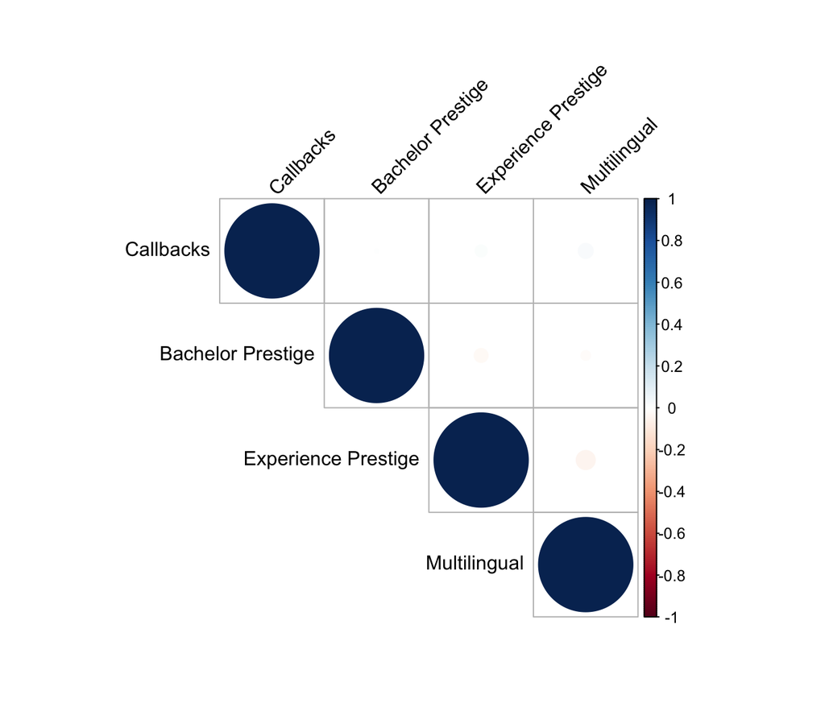

```r
#Creates a dataframe of the columns we would like to view the correlations in
cordf <-
  df %>%
  select(callback, ba_quality, exp_highquality, language_skills) %>%
  rename(c("Callbacks" = callback, "Bachelor Prestige" = ba_quality, "Experience Prestige" = exp_highquality, "Multilingual" = language_skills))

corrplot(cor(cordf), type = "upper", tl.col = "black", tl.srt = 45)
```

It seems as though there is no correlation among the variables. This is good because there is no multicolinearity, but also may be bad because there may be no relationship.

### 5.4.3 Histograms

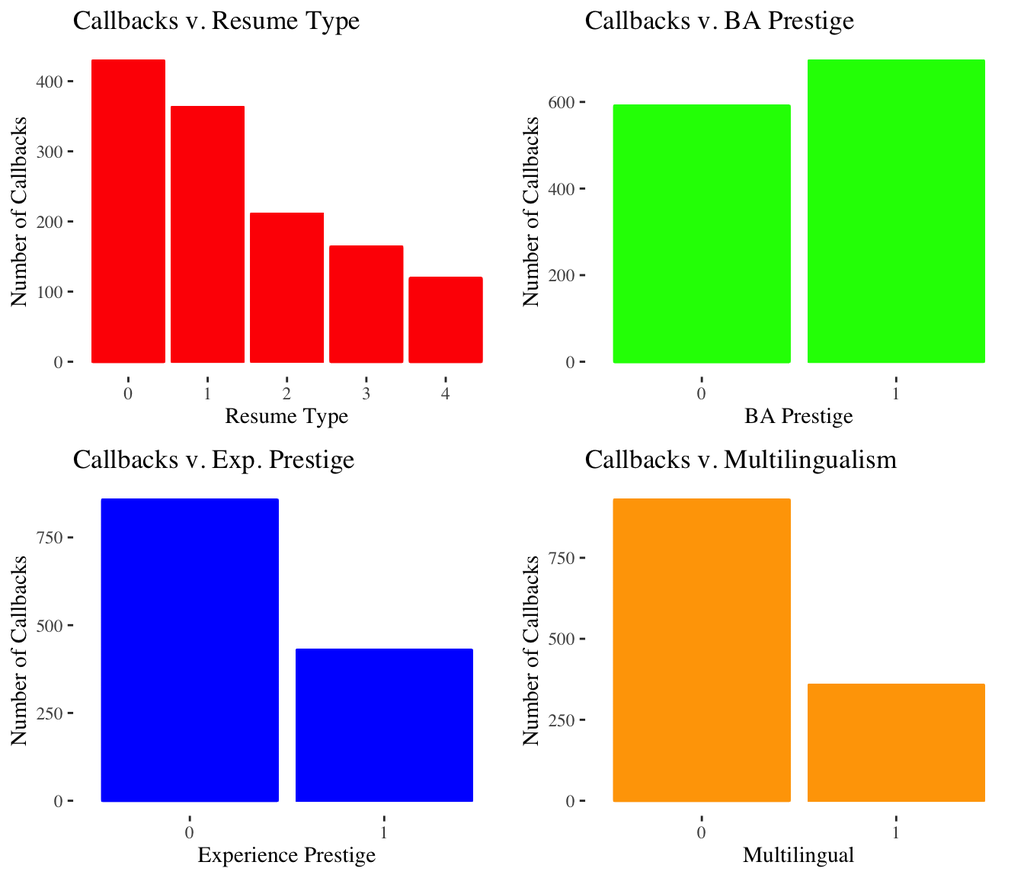

```r
#Creates a histogram for resume type
p1 <-
  ggplot(df, aes(x = type, y = callback)) +
  geom_histogram(stat = "identity", col = "red") +
  labs(y = "Number of Callbacks", x = "Resume Type", title = "Callbacks v. Resume Type") +
  theme_tufte()

#Creates a histogram for bachelor's degree prestige
p2 <-
  ggplot(df, aes(x = factor(ba_quality), y = callback)) +
  geom_histogram(stat = "identity", col = "green") +
  labs(y = "Number of Callbacks", x = "BA Prestige", title = "Callbacks v. BA Prestige") +
  theme_tufte()

#Creates a histogram for experience prestige
p3 <-
  ggplot(df, aes(x = factor(exp_highquality), y = callback)) +
  geom_histogram(stat = "identity", col = "blue") +
  labs(y = "Number of Callbacks", x = "Experience Prestige", title = "Callbacks v. Exp. Prestige") +
  theme_tufte()

#Creates a histogram for multilingualism
p4 <-
  ggplot(df, aes(x = factor(language_skills), y = callback)) +
  geom_histogram(stat = "identity", col = "orange") +
  labs(y = "Number of Callbacks", x = "Multilingual", title = "Callbacks v. Multilingualism") +
  theme_tufte()

#Puts plots on a 2x2 grid
plot_grid(p1, p2, p3, p4)
```

At first glance, it seems as though the more foreign the person’s background is (name, education, experience), the less callbacks the person receives. It also seems like BA prestige has a small positive effect, but experience and multilingual ability has a negative effect! However, I will once again be very skeptical of these preliminary visual results because most of the data heavily skews towards `FALSE = 0`. I will verify these exploratory results by running a regression and printing more statistically robust findings to a table.

## 5.5 Statistical Analysis

### 5.5.1 Model Results

Now that I have a good understanding of what things should look like, I will now run the regression.

```r
stargazer(m1, m2, m3,
          type = "html",
          title = "Estimated Effects on the Probability of Callback from the Inclusion of Specific Resume Characteristics",

          covariate.labels = c("Resume Type", "BA Prestige", "Resume Type:BA Prestige", "Experience Prestige", "Resume Type:Experience Prestige", "Multilingual", "Resume Type:Multilingual"))
```

**Estimated Effects on the Probability of Callback from the Inclusion of Specific Resume Characteristics**

|  | *Dependent variable:* |  |  |
| --- | --- | --- | --- |
|  | callback |  |  |
|  | (1) | (2) | (3) |
| Resume Type | -0.020*** | -0.019*** | -0.018*** |
|  | (0.003) | (0.002) | (0.002) |
| BA Prestige | -0.012 |  |  |
|  | (0.009) |  |  |
| Resume Type:BA Prestige | 0.003 |  |  |
|  | (0.004) |  |  |
| Experience Prestige |  | 0.004 |  |
|  |  | (0.009) |  |
| Resume Type:Experience Prestige |  | 0.003 |  |
|  |  | (0.004) |  |
| Multilingual |  |  | 0.018* |
|  |  |  | (0.010) |
| Resume Type:Multilingual |  |  | -0.001 |
|  |  |  | (0.004) |
| Constant | 0.138*** | 0.130*** | 0.127*** |
|  | (0.007) | (0.005) | (0.005) |
| Observations | 12,910 | 12,910 | 12,910 |
| R<sup>2</sup> | 0.007 | 0.007 | 0.008 |
| Adjusted R<sup>2</sup> | 0.007 | 0.007 | 0.008 |
| Residual Std. Error (df = 12906) | 0.298 | 0.298 | 0.298 |
| F Statistic (df = 3; 12906) | 31.764*** | 32.089*** | 33.528*** |
| *Note:* | p<0.1; p<0.05; p<0.01 |  |  |

According to the regression, BA prestige, experience prestige, and multilingualism do not have significant effects, although multilingualism has a small effect which is significant at the 10% level. In addition, my hypothesis that foreign backgrounds harm callbacks held true at the 1% level. To make these stronger, I will perform t-tests at the individual level.

### 5.5.3 Confidence Intervals for $\beta$ parameter estimates

```r
#Creates confidence intervals
confint(m1) %>% kable(caption="Bachelor's Degree Prestige", digits = 3)
```

Bachelor’s Degree Prestige

|  | 2.5 % | 97.5 % |
| --- | --- | --- |
| (Intercept) | 0.125 | 0.151 |
| type | -0.026 | -0.015 |
| ba_quality | -0.028 | 0.005 |
| type:ba_quality | -0.004 | 0.011 |

```r
confint(m2) %>% kable(caption="Work Experience Prestige", digits = 3)
```

Work Experience Prestige

|  | 2.5 % | 97.5 % |
| --- | --- | --- |
| (Intercept) | 0.120 | 0.140 |
| type | -0.024 | -0.015 |
| exp_highquality | -0.013 | 0.022 |
| type:exp_highquality | -0.005 | 0.011 |

```r
confint(m3) %>% kable(caption="Multilingual Ability", digits = 3)
```

Multilingual Ability

|  | 2.5 % | 97.5 % |
| --- | --- | --- |
| (Intercept) | 0.117 | 0.136 |
| type | -0.022 | -0.014 |
| language_skills | -0.001 | 0.037 |
| type:language_skills | -0.010 | 0.008 |

### 5.5.4 Hypothesis Testing

There is no reason for us to test heteroskedasticity, but we will check the significance of these results. If we were to suspect heteroskedasticity, I would use the Breush-Pagan test using the library `lmtest`.

#### 5.5.4.1 t-testing

Under all models, we see a statistically significant effect of `Resume Type` at the 1% level.

```r
kable(summary(m1)$coefficients, digits = 3, caption = "Model 1: Bachelor's Degree Prestige")
```

Model 1: Bachelor’s Degree Prestige

|  | Estimate | Std. Error | t value | Pr(>\|t\|) |
| --- | --- | --- | --- | --- |
| (Intercept) | 0.138 | 0.007 | 21.068 | 0.000 |
| type | -0.020 | 0.003 | -7.378 | 0.000 |
| ba_quality | -0.012 | 0.009 | -1.372 | 0.170 |
| type:ba_quality | 0.003 | 0.004 | 0.843 | 0.399 |

**We fail to reject the null hypothesis $H0: \beta_{BA\_quality} = 0$**

```r
kable(summary(m2)$coefficients, digits = 3, caption = "Model 2: Work Experience Prestige")
```

Model 2: Work Experience Prestige

|  | Estimate | Std. Error | t value | Pr(>\|t\|) |
| --- | --- | --- | --- | --- |
| (Intercept) | 0.130 | 0.005 | 25.484 | 0.000 |
| type | -0.019 | 0.002 | -8.343 | 0.000 |
| exp_highquality | 0.004 | 0.009 | 0.495 | 0.620 |
| type:exp_highquality | 0.003 | 0.004 | 0.664 | 0.506 |

**We fail to reject the null hypothesis $H0: \beta_{workexp\_quality} = 0$**

```r
kable(summary(m3)$coefficients, digits = 3, caption = "Model 3: Multilingual Ability")
```

Model 3: Multilingual Ability

|  | Estimate | Std. Error | t value | Pr(>\|t\|) |
| --- | --- | --- | --- | --- |
| (Intercept) | 0.127 | 0.005 | 26.202 | 0.000 |
| type | -0.018 | 0.002 | -8.273 | 0.000 |
| language_skills | 0.018 | 0.010 | 1.871 | 0.061 |
| type:language_skills | -0.001 | 0.004 | -0.232 | 0.817 |

**We fail to reject the null hypothesis $H0: \beta_{multilingual} = 0$. However, we can accept some small affect at the 10% level**

#### 5.5.4.2 F-testing using ANOVA

The F-test will measure whether there is a joint significance among the indicator variables.

```r
restricted.model <- lm(callback ~ type, data = df)
```

Model 1: Bachelor Prestige

```r
format(anova(restricted.model, m1), digits = 3)
```

|  | Res.Df | RSS | Df | Sum of Sq | F | Pr(>F) |
| --- | --- | --- | --- | --- | --- | --- |
| 1 | 12908 | 1150 | NA | NA | NA | NA |
| 2 | 12906 | 1149 | 2 | 0.18 | 1.01 | 0.365 |

**We fail to reject the null hypothesis $H0: \beta_{BA\_quality} = 0$**

Model 2: Work Experience Prestige

```r
format(anova(restricted.model, m2), digits = 3)
```

|  | Res.Df | RSS | Df | Sum of Sq | F | Pr(>F) |
| --- | --- | --- | --- | --- | --- | --- |
| 1 | 12908 | 1150 | NA | NA | NA | NA |
| 2 | 12906 | 1149 | 2 | 0.266 | 1.49 | 0.225 |

**We fail to reject the null hypothesis $H0: \beta_{workexp\_quality} = 0$**

Model 3: Multilingual Ability

```r
format(anova(restricted.model, m3), digits = 3)
```

|  | Res.Df | RSS | Df | Sum of Sq | F | Pr(>F) |
| --- | --- | --- | --- | --- | --- | --- |
| 1 | 12908 | 1150 | NA | NA | NA | NA |
| 2 | 12906 | 1149 | 2 | 0.647 | 3.63 | 0.0264 |

**Because p < 0.05, we reject the null hypothesis $H0: \beta_{multilingual} = 0$ and accept the alternative that $H0: \beta_{multilingual} \neq 0$.**

# 6 Conclusion

## 6.1 Answer to research question

There is significant discrimination based on the person’s level of separation from the home country. Foreign names, foreign work experience, and foreign educational institutions all contribute to receiving fewer callbacks.

We cannot say that bachelor’s degree prestige or experience prestige has an effect on curbing this discrimination. However, it seems as though multilingual abilities matter slightly. According to the author of the original study, Philip Oreopoulos, most employers were concerned about an applicant’s ability to speak English. They feared strong acents and not being understood by customers or coworkers. Names suggest fluency problems, work eligibility, long vacations to visit family/friends, and additional time off for cultural holidays *(Oreopoulos 2011, p. 166)*.

## 6.2 Literature Review

This is supported by *Crandall and Eshleman (2003)* who analyzed unintentional implicit discrimination and found that employers make assumptions based on people’s names. They assume immigration status and poor language skills.

Another study by *Dan-Olof Rooth (2010)* finds discrimination from Arab-Muslim names.

There are also similar results found by *Bertrand, Chugh, and Mullainathan (2005)*. However, they see name-based discrimination between African-American names.

Lastly, *Heblich et al. (2015)* have found that accents do make a difference and there is a large concern around them. They say that they demonstrate that out-group accents lead to both social discrimination and economic decisions. This discrimination is based on social ratings of linguistic distance and the in-group/out-group perceptions.

## 6.3 Policy Implications

One immediate recommendation that is supported by *Oreopoulos (2011)* is that we should mask names to prevent discrimination. He also says that *Goldin and Rouse (2000)* document blind audition procedures fostering impartiality in hiring procedures.

## 6.4 Suggestions to improve model or experiment

This study was done well. However, I would recommend having a more even proportion of indicator variables. `ba_quality` was the only variable that was represented near `50%`. However, I understand that this is difficult because of the sheer number of variables.

# 7 Works Cited

**Bertrand, Marianne, Dolly Chugh, and Sendhil Mullainathan.** 2005. “Implicit Discrimination.” *American Economic Review*, 95(2): 94–98.

**Goldin, Claudia, and Cecilia Rouse.** 2000. “Orchestrating Impartiality: The Impact of ‘Blind’ Auditions on Female Musicians.” *American Economic Review*, 90(4): 715–41.

**Crandall, Christian S., and Amy Eshleman.** 2003. “A Justification-Suppression Model of the Expression and Experience of Prejudice.” *Psychological Bulletin*, 129(3): 414–46.

**Heblich, S., Lameli, A., & Riener, G. (2015)**. The effect of perceived regional accents on individual economic behavior: a lab experiment on linguistic performance, cognitive ratings and economic decisions. *PloS one*, 10(2), e0113475. https://doi.org/10.1371/journal.pone.0113475

**Oreopoulos, Philip.** 2018, “Replication Data for: Why Do Skilled Immigrants Struggle in the Labor Market? A Field Experiment with Thirteen Thousand Resumes”, https://doi.org/10.7910/DVN/WXMJCN, *Harvard Dataverse*, V1

**Rooth, Dan-Olof.** 2010. “Automatic Associations and Discrimination in Hiring: Real World Evidence.” *Labour Economics*, 17(3): 523–34.